# Operations on shapes

### Slicing

#### Based on geometry

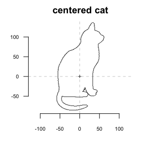

```r
shp %>% coo_center %>% coo_plot(main="centered cat")
```

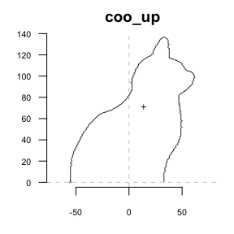

```r
shp %>% coo_center %>% coo_up() %>% coo_plot(main="coo_up")
```

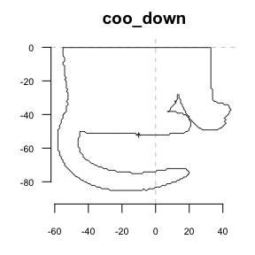

```r
shp %>% coo_center %>% coo_down() %>% coo_plot(main="coo_down")
```

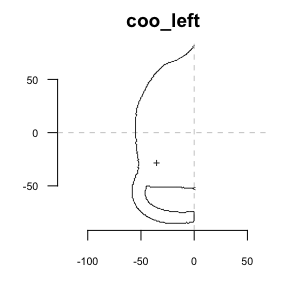

```r
shp %>% coo_center %>% coo_left() %>% coo_plot(main="coo_left")
```

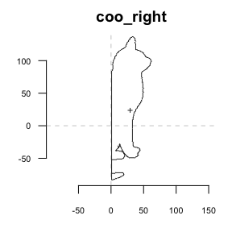

```r
shp %>% coo_center %>% coo_right() %>% coo_plot(main="coo_right")
```

If you want to slice but want the first point to be on one end, then `coo_slidegap` is your friend :

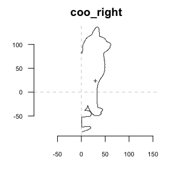

```r
shp %>% coo_center %>% coo_right() %>% coo_slidegap %>% coo_plot(main="coo_right")
```

#### Based on landmarks

`coo_slice` results in at least two shapes. Should be more useful with the argument `ldk` and within a `Coo`.

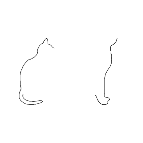

```r
shp %>% coo_center %>% coo_slice(ids=c(93, 516)) %>% Opn %>% panel()
```

### Indexing

#### Sliding

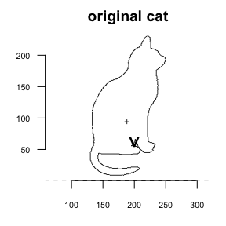

```r
shp %>% coo_plot(main="original cat", cex.first.point = 2)
```

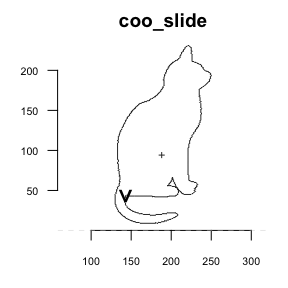

```r
shp %>% coo_slide(id=93) %>% coo_plot(main="coo_slide", cex.first.point = 2) # same comment for ldk/Coo as for coo_slice
```

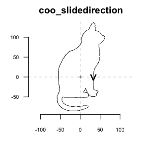

```r
shp %>% coo_slidedirection("right") %>%  coo_plot(main="coo_slidedirection", cex.first.point = 2)
```

#### Closing/opening

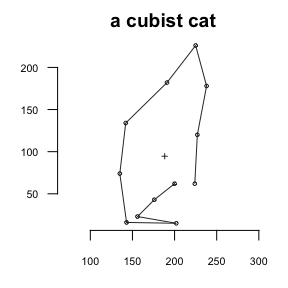

```r
shp12 <- shp %>% coo_sample(12)
shp12 %>% coo_plot(main="a cubist cat")
```

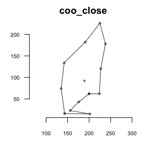

```r
shp12 %>% coo_close %>% coo_plot(main="coo_close")
```

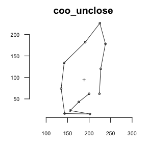

```r
shp12 %>% coo_close %>% coo_unclose %>% coo_plot(main="coo_unclose")
```

#### Trimming/extracting

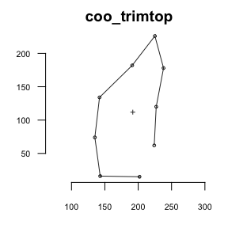

```r
shp12 %>% coo_trimtop(3) %>% coo_plot(main="coo_trimtop")
```

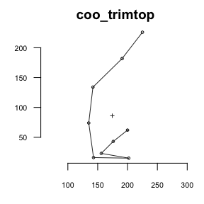

```r
shp12 %>% coo_trimbottom(3) %>% coo_plot(main="coo_trimtop")
```

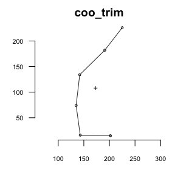

```r
shp12 %>% coo_trim(3) %>% coo_plot(main="coo_trim")
```

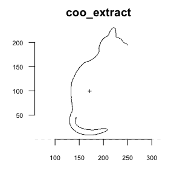

```r
shp %>% coo_extract(93:516) %>% coo_plot(main="coo_extract")
```

#### Reversing

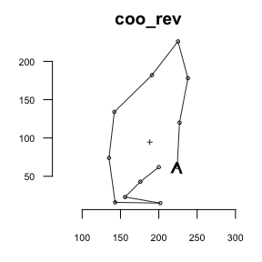

```r
shp12 %>% coo_rev %>% coo_plot(main="coo_rev", cex.first.point = 2)
```

### Misc

A side effect of `coo_dxy` is to set the first point on `(0, 0)`

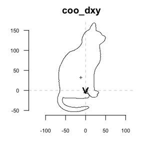

```r
shp %>% coo_dxy %>% coo_plot(main="coo_dxy", cex.first.point = 2)
```

`coo_force2close` can be use to spread differences between the first and last point, and to force closing:

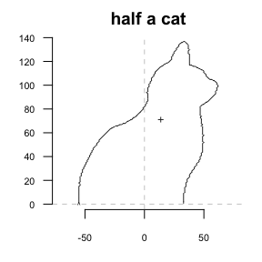

```r
shp %>% coo_center %>% coo_up %>% coo_plot(main="half a cat")
```

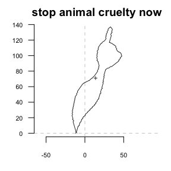

```r
shp %>% coo_center %>% coo_up %>% coo_force2close %>% coo_plot(main="stop animal cruelty now")
```

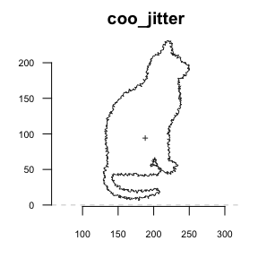

```r
# for the sake of reproducibility
set.seed(123)
shp %>% coo_jitter(factor=10) %>% coo_plot(main="coo_jitter")
```

## Other coo operations

```r
# coo_descriptors along
coo_centdist
coo_perimcum
coo_perimpts



# coo_descriptors non-scalars
coo_boundingbox
coo_centpos # should be a df?
coo_chull
coo_chull_onion
coo_diffrange # coo_range_diff
coo_lw
coo_truss

coo_range
coo_range_enlarge

# coo_drawers
coo_arrows
coo_draw
coo_draw_rads
coo_listpanel
coo_lolli
coo_oscillo # deprecate for a proper oscillo
coo_plot
coo_ruban

# coo_others
coo_angle_edges
coo_angle_tangent

coo_intersect_angle
coo_intersect_direction
coo_intersect_segment

# coo_testers
coo_is_closed
coo_likely_anticlockwise
coo_likely_clockwise

# helpers
coo_check
coo_nb

coo_ldk
```